# Assignment 7: Visualization - Some aspects of ggplot2

*How to do it?*:

- Open the Rmarkdown file of this assignment (link) in Rstudio.
- Right under each **question**, insert a code chunk (you can use the hotkey `Ctrl + Alt + I` to add a code chunk) and code the solution for the question.
- `Knit` the rmarkdown file (hotkey: `Ctrl + Alt + K`) to export an html.
- Publish the html file to your Githiub Page.

*Submission*: Submit the link on Github of the assignment to Canvas

Use the data of your own. Produce the following types of plots and comment on each plot. Plots should be meaningful. If you use the data we used in class, make sure the plots are not the same as the ones in the slides. All plots should have title, caption, appropriate labels on x and y-axis.

1. Make a plot using `facet_wrap` by one categorical variable (`facet_wrap(~variable1)`)

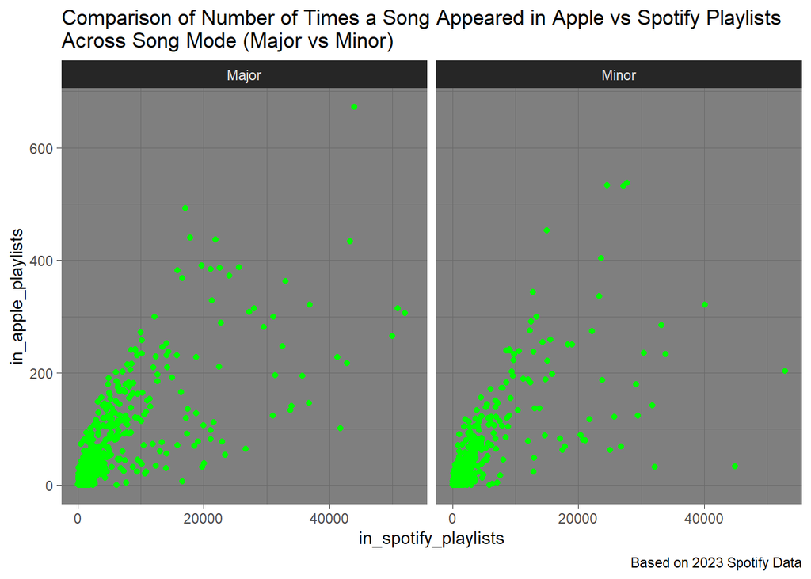

```r
# Calling libraries
library(tidyverse)
library(dplyr)
library(ggplot2)

# Reading in data
df <- read_csv('spotify-2023.csv')

# Creating plot to compare the number of times a song appeared in Apple playlists and Spotify playlists across song mode
ggplot(df, aes(x=in_spotify_playlists, y=in_apple_playlists)) + geom_point(color='Green') + facet_wrap(~mode, ncol=3) + theme_dark() + ggtitle("Comparison of Number of Times a Song Appeared in Apple vs Spotify Playlists\nAcross Song Mode (Major vs Minor)") + labs(caption = "Based on 2023 Spotify Data") + theme(plot.caption = element_text(hjust=1))
```

```r
# Regardless of song mode, the correlation between the number of times a song appears on Apple and Spotify playlists appears similar (both relatively positive). However this correlation appears to be slightly stronger for Major songs.

# The commented out line of code below was used to save this plot so I could place it on my Github site
# ggsave("my_saved_plot.png")
```

2. Make a plot using `facet_wrap` by two categorical variables (`facet_wrap(~variable1+variable2)`)

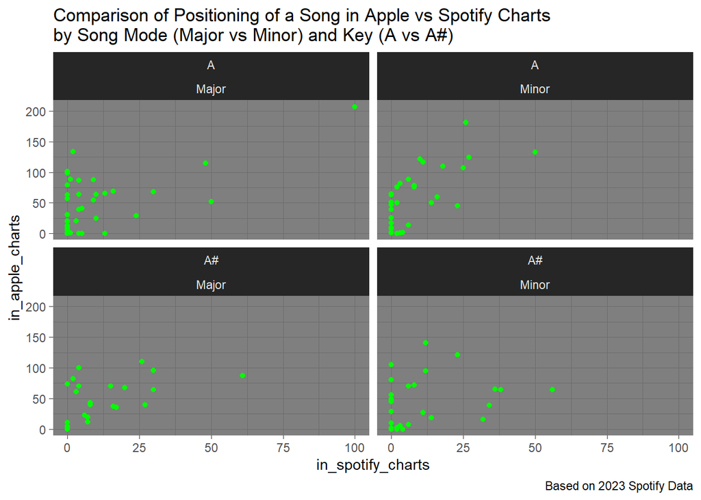

```r
# Creating a filtered df to only include songs that were written in the keys A or A#
filtered_df_1 <- df %>% filter(substr(df$key,1,1) == 'A')

# Creating a plot to compare the positioning of a song in Apple vs Spotify charts based on the song mode and key
ggplot(filtered_df_1, aes(x=in_spotify_charts, y=in_apple_charts)) + geom_point(color='Green') + facet_wrap(~key+mode) + theme_dark() + ggtitle("Comparison of Positioning of a Song in Apple vs Spotify Charts\nby Song Mode (Major vs Minor) and Key (A vs A#)") + labs(caption = "Based on 2023 Spotify Data") + theme(plot.caption = element_text(hjust=1))
```

```r
# It appears that the strongest positive correlation between song positioning in Apple and Spotify charts occurs with minor songs that were written in the A key. The weakest correlation appears to occur with minor songs written in the A# key.
```

3. Make a plot using `position ='dodge'`.

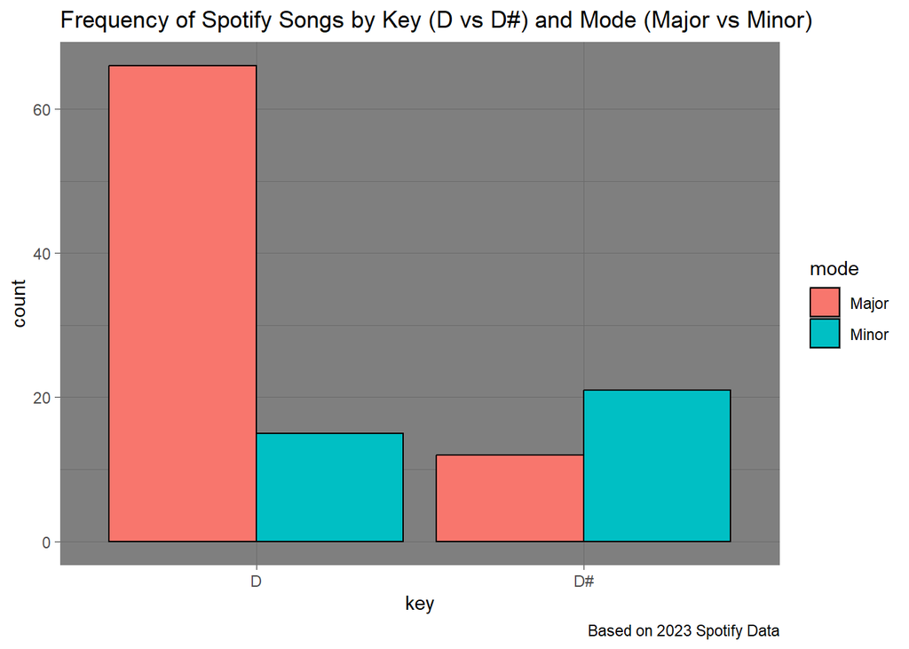

```r
# Filtering df to only incldue songs written in keys D & D#
filtered_df_2 <- df %>% filter(substr(df$key,1,1) == 'D')

# Plotting the frequency of songs based on their key (D &) and mode
ggplot(filtered_df_2, aes(x=key, fill=mode)) + geom_bar(position = 'dodge', na.rm = TRUE, color='Black') + theme_dark() + ggtitle("Frequency of Spotify Songs by Key (D vs D#) and Mode (Major vs Minor)") + labs(caption = "Based on 2023 Spotify Data") + theme(plot.caption = element_text(hjust=1))
```

```r
# The majority of songs in this subset of the data are major songs written in the D key. Interestingly, even though there are many more major songs written in the D key, there are actually more minor songs than major written in the D# key.
```

4. Make a plot using `position ='fill'`.

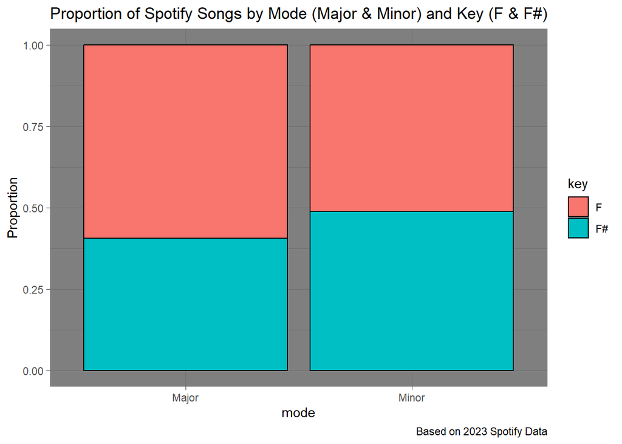

```r
# Filtering df to only include songs written in F and F# keys
filtered_df_3 <- df %>% filter(substr(df$key,1,1) == 'F')

# Creating a plot to show the proportion of songs by mode and key (F & F#)
ggplot(filtered_df_3, aes(x=mode, fill=key)) + geom_bar(position = 'fill', na.rm = TRUE, color='Black') + theme_dark() + ggtitle("Proportion of Spotify Songs by Mode (Major & Minor) and Key (F & F#)") + labs(caption = "Based on 2023 Spotify Data") + theme(plot.caption = element_text(hjust=1)) + labs(y='Proportion')
```

```r
# It appears that the proportion of minor songs is nearly evenly split between being written in the F & F# keys, while there is a less even split for major songs (with around 60% of these songs being written in the F key and only around 40% written in F#).
```

5. Make a plot using `geom_col`.

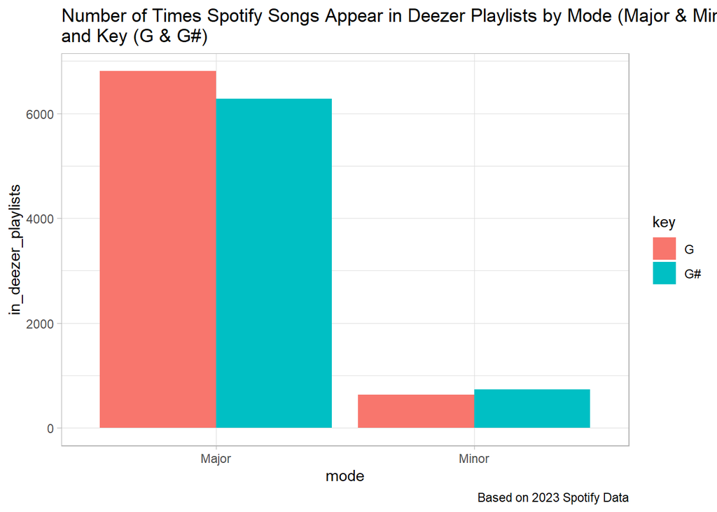

```r
# Filtering df to only include songs written in the G & G# keys
filtered_df_4 <- df %>% filter(substr(df$key,1,1) == 'G')

# Plotting the number of times a song appeared in Deezer playlists based on their mode and key (G or G#)
ggplot(filtered_df_4, aes(x=mode, y=in_deezer_playlists, fill=key)) + geom_col(na.rm = TRUE, position = 'dodge') + theme_light() + ggtitle("Number of Times Spotify Songs Appear in Deezer Playlists by Mode (Major & Minor)\nand Key (G & G#)") + labs(caption = "Based on 2023 Spotify Data") + theme(plot.caption = element_text(hjust=1))
```

```r
# Many more major songs written in the G and G# keys appeared in Deezer playlists in comparison to the minor songs written in G and G#. Interestingly as well, songs written in the G key were in more Deezer playlists for major songs, while more minor songs written in the G# key were found in Deezer playlists.
```

6. Change the theme of one of your plots.

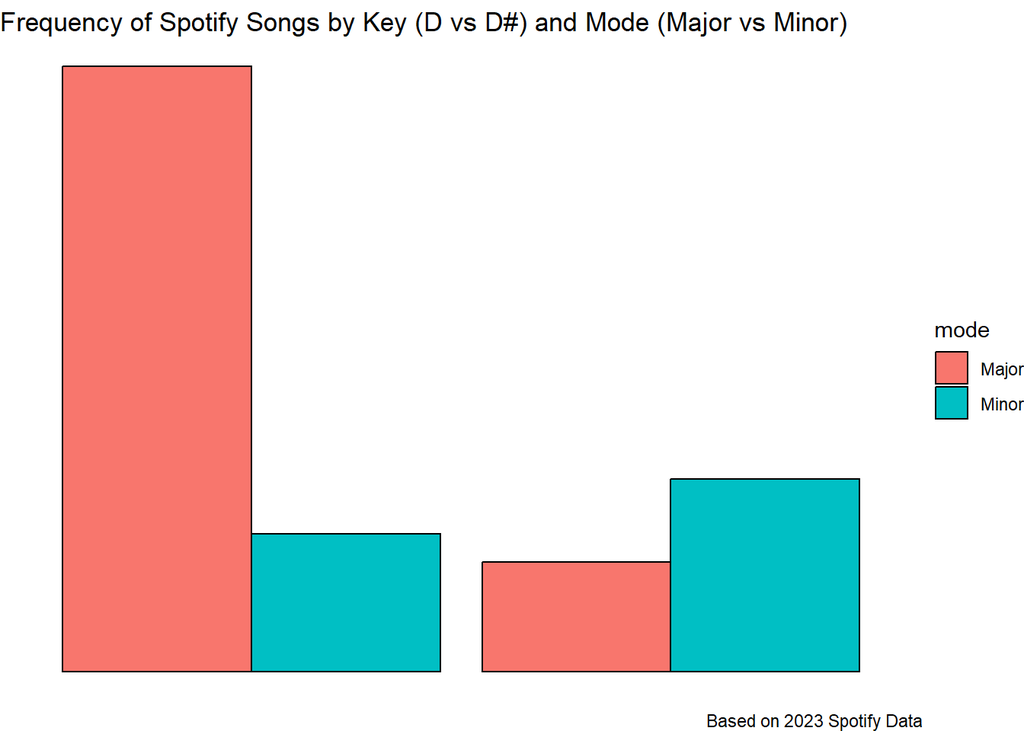

```r
# Changed the theme of my plot for #3 to theme_void()
ggplot(filtered_df_2, aes(x=key, fill=mode)) + geom_bar(position = 'dodge', na.rm = TRUE, color='Black') + theme_void() + ggtitle("Frequency of Spotify Songs by Key (D vs D#) and Mode (Major vs Minor)") + labs(caption = "Based on 2023 Spotify Data") + theme(plot.caption = element_text(hjust=1))
```